# A4Q3

Yuqi Gu

7/22/2024

### (a)

```r
water.dat <- read.table("~/Desktop/STAT 332/Assignments/A4/water.txt")
names(water.dat) <- c("burner", "salt", "time")
water.dat$burner <- as.factor(water.dat$burner)
water.dat$salt <- as.factor(water.dat$salt)
water.aov <- aov(time ~ burner + salt + burner:salt, data = water.dat)
summary(water.aov)
```

```
##             Df Sum Sq Mean Sq F value   Pr(>F)
## burner       3 110.50   36.83  73.667 1.86e-14 ***
## salt         3   6.83    2.28   4.556  0.00909 **
## burner:salt  9   3.33    0.37   0.741  0.66931
## Residuals   32  16.00    0.50
## ---
## Signif. codes:  0 '***' 0.001 '**' 0.01 '*' 0.05 '.' 0.1 ' ' 1
```

### (b)

```r
qf(0.95, 9, 32) #Test for interactions
```

```
## [1] 2.188766
```

```r
qf(0.95, 3, 32) #Test for main effects of burner
```

```
## [1] 2.90112
```

```r
qf(0.95, 3, 32) #Test for main effects of salt
```

```
## [1] 2.90112
```

Since 0.741 < 2.188766 and the corresponding p-value is 0.66931 , we do not reject the null hypothesis. Consequently, the interactions between burner and salt are not significant for the mean time to boiling. Thus, the mean time to boiling stay the same if the interactions between salt and burner are different. Since 73.667 > 2.90112 and the corresponding p-value is 1.86e-14, which is much smaller than 0.05, we reject H0. Thus, we conclude that the effect of burner on mean time to boiling is significantly important. Thus, at the 5% level, the mean time to boiling differs if the burners are different. Since 4.556 > 2.90112 and the corresponding p-value is 0.00909, which is smaller than 0.05, we reject H0. Thus, we conclude that the effect of salt on mean time to boiling is significantly important. Thus, at the 5% level, the mean time to boiling differs if the numbers of teaspoons of salt are different.

### (c)

```r
TukeyHSD(water.aov, "burner", conf.level=0.95)
```

```
##   Tukey multiple comparisons of means
##     95% family-wise confidence level
##
## Fit: aov(formula = time ~ burner + salt + burner:salt, data = water.dat)
##
## $burner
##           diff        lwr       upr     p adj
## 2-1 -2.5000000 -3.2821253 -1.717875 0.0000000
## 3-1 -0.5833333 -1.3654587  0.198792 0.2016864
## 4-1  1.7500000  0.9678747  2.532125 0.0000052
## 3-2  1.9166667  1.1345413  2.698792 0.0000010
## 4-2  4.2500000  3.4678747  5.032125 0.0000000
## 4-3  2.3333333  1.5512080  3.115459 0.0000000
```

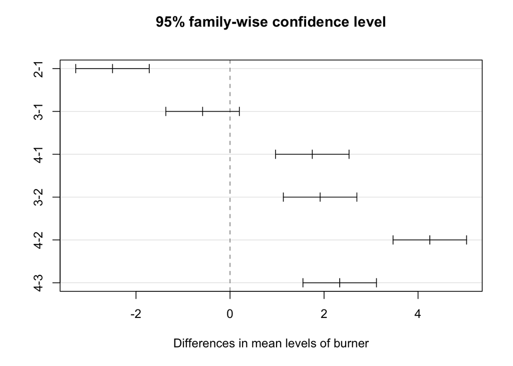

```r
plot(TukeyHSD(water.aov, "burner"))
```

The right-front burner, which is 2 burner, is the fastest at boiling water. This is because the difference of 2-1 is -2.5000000, that of 3-2 is 1.9166667, and that of 4-2 is 4.2500000. In other words, the time to boiling of burner 2 is 2.5 minutes shorter than that of burner 1. The time to boiling of burner 2 is 1.92 minutes shorter than that of burner 3. The time to boiling of burner 2 is 4.25 minutes short than that of burner 4. Also, the time to boiling of burner 3 is 0.58 minutes shorter than that of burner 1. The time to boiling of burner 4 is 1.75 longer than that of burner 1 and the time to boiling of burner 4 is 2.33 longer than that of burner 3.